# Energy Data Merge V1

Keenan Wallace

# Load Datasets

```r
train <- read_csv("data/train.csv")
```

```r
mapping <- read_csv("data/weather_station_to_county_mapping.csv")
historical_weather <- read_csv("data/historical_weather.csv")
client <- read_csv("data/client.csv")
gas_prices <- read_csv("data/gas_prices.csv")
electricity_prices <- read_csv("data/electricity_prices.csv")
forecast_weather <- read_csv("data/forecast_weather.csv")
```

# Separate Train and Test Sets

```r
test <- train[train$data_block_id >= 634,]
train <- train[train$data_block_id < 634,]
#Last data blocks of the time series(634-637) separated as test set
```

# Testing Data

## Weather Aggregation by Region

### Round

```r
mapping <- na.omit(mapping)
mapping$longitude <- round(mapping$longitude,1)
mapping$latitude <- round(mapping$latitude,1)
#eliminate infinite values
```

### Merge region mapping with forecast weather

```r
forecast_weather$latitude <- round(forecast_weather$latitude,1)
forecast_weather$longitude <- round(forecast_weather$longitude,1) #eliminate infinite values
fweather <- left_join(forecast_weather, mapping %>% distinct(longitude, latitude, county), by = c("longitude", "latitude")) #map county to longitude & latitude in fweather
fweather <- na.omit(fweather)
```

### Aggregate temperatures by date and region

```r
#Summarize weather data across coordinates in each county by the hour
fweather_av <- fweather %>%
  group_by(origin_datetime, forecast_datetime, county) %>%
  summarize(temperature = mean(temperature))
```

```
## can override using the `.groups` argument.
```

```r
fweather_rad <- fweather %>%
  group_by(origin_datetime, forecast_datetime, county) %>%
  summarize(direct_solar_radiation = mean(direct_solar_radiation))
```

```
## can override using the `.groups` argument.
```

```r
fweather_prec <- fweather %>%
  group_by(origin_datetime, forecast_datetime, county) %>%
  summarize(total_precipitation = mean(total_precipitation))
```

```
## can override using the `.groups` argument.
```

```r
fweather_dew <- fweather %>%
  group_by(origin_datetime, forecast_datetime, county) %>%
  summarize(dewpoint = mean(dewpoint))
```

```
## can override using the `.groups` argument.
```

```r
fweather_data_id <- fweather %>%
  group_by(origin_datetime) %>%
  summarize(data_block_id = mean(data_block_id))

# Merge the datasets into fweather_av
fweather_av$direct_solar_radiation <- fweather_rad$direct_solar_radiation
fweather_av$total_precipitation <- fweather_prec$total_precipitation
fweather_av$dewpoint <- fweather_dew$dewpoint
fweather_av <- left_join(fweather_av, fweather_data_id, by = "origin_datetime")
fweather_av <- left_join(fweather_av, fweather %>% distinct(origin_datetime, hours_ahead, forecast_datetime), by = c("origin_datetime", "forecast_datetime"))
```

For the test set, I am using forecast data as the true weather data will not be available when making the prediction.

## Merge forecast weather with test data

```r
test_weather <- fweather_av[fweather_av$data_block_id >= 634,]
test_weather <- test_weather %>% rename(datetime = forecast_datetime)
test <- left_join(test, test_weather, by = c("data_block_id", "datetime", "county"))
```

## Merge Client with Test

```r
test <- left_join(test, client %>% distinct(data_block_id, is_business, county, product_type, eic_count, installed_capacity), by = c("data_block_id", "is_business", "product_type", "county"))
```

## Merge Gas Prices with Test

```r
test <- left_join(test, gas_prices %>% distinct(data_block_id, lowest_price_per_mwh, highest_price_per_mwh), by = "data_block_id")
```

## Merge Electricity Prices with Test

```r
electricity_prices <- separate(electricity_prices, forecast_date, c("date", "time"), sep = " ")
electricity_prices <- electricity_prices[electricity_prices$time == "10:00",]
test <- left_join(test, electricity_prices %>% distinct(data_block_id, euros_per_mwh), by = "data_block_id")
```

Only electricity prices available at 10:00am the day prior will be used for the next day’s prediction, as predictions are made at 11am.

```r
test <- na.omit(test)
```

192 rows omitted of 12480

# Train

## Historical weather aggregation by region

### Merge mapping file with with historical weather

```r
historical_weather$latitude <- round(historical_weather$latitude,1)
historical_weather$longitude <- round(historical_weather$longitude,1)
hweather <- left_join(historical_weather, mapping %>% distinct(longitude, latitude, county), by = c("longitude", "latitude"))
hweather <- na.omit(hweather)
```

### Aggregate historical weather by date and region

```r
hweather$total_precipitation <- hweather$snowfall/10 + hweather$rain
#to keep factors consistent between historical and forecast weather

#Summarize weather data across coordinates in each county by the hour
hweather_av <- hweather %>%
  group_by(datetime, county) %>%
  summarize(temperature = mean(temperature))
hweather_rad <- hweather %>%
  group_by(datetime, county) %>%
  summarize(direct_solar_radiation = mean(direct_solar_radiation))
hweather_prec <- hweather %>%
  group_by(datetime, county) %>%
  summarize(total_precipitation = mean(total_precipitation))
hweather_dew <- hweather %>%
  group_by(datetime, county) %>%
  summarize(dewpoint = mean(dewpoint))
#Merge the datasets into hweather_av
hweather_av$direct_solar_radiation <- hweather_rad$direct_solar_radiation
hweather_av$total_precipitation <- hweather_prec$total_precipitation
hweather_av$dewpoint <- hweather_dew$dewpoint
```

## Merge weather to train

```r
train <- left_join(train, hweather_av, by = c("county", "datetime"))
```

Historical data is merged only by county and datetime as the true weather for each time will be used to train the data, rather than a forecast prediction like is used in test.

## Merge client to train

```r
train$datetime2 <- train$datetime
train <- separate(train, datetime2, c("date", "time"), sep = " ")

train$date <- as.POSIXct(train$date, format = "%Y-%m-%d")

train <- left_join(train, client %>% distinct(date, is_business, county, product_type, eic_count, installed_capacity), by = c("date", "is_business", "product_type", "county"))
```

## Merge gas to train

```r
gas_prices$date <- as.POSIXct(gas_prices$forecast_date, format = "%m/%d/%y")
train <- left_join(train, gas_prices %>% distinct(date, lowest_price_per_mwh, highest_price_per_mwh), by = "date")
```

# Merge electricity to train

```r
electricity_prices <- read_csv("data/electricity_prices.csv")
electricity_prices$datetime <- as.POSIXct(electricity_prices$forecast_date, format = "%m/%d/%y %H:%M")
electricity_prices$datetime <- electricity_prices$datetime - hours(4) #fixes shift in data created by the merge
train <- left_join(train, electricity_prices %>% distinct(datetime, euros_per_mwh), by = "datetime")
```

```r
train <- na.omit(train)
```

31734 rows omitted of 2005872

# Export sets

```r
write.csv(train, "/Users/kwallace/ISP_2024/data/train_set1.csv", row.names=FALSE)
write.csv(test, "/Users/kwallace/ISP_2024/data/test_set1.csv", row.names=FALSE)
#for use in other programs
```

# Machine Learning Models

## Linear Regression

### Looking at only energy consumption

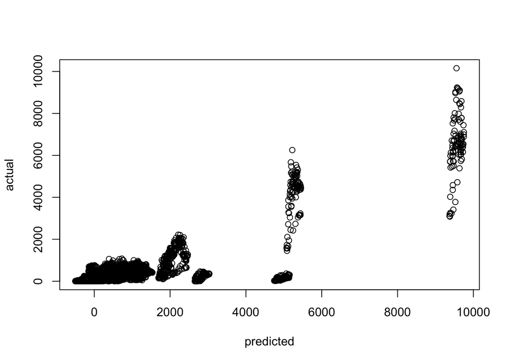

```r
trainlm <- lm(target ~ as.factor(is_business) + temperature + direct_solar_radiation + total_precipitation + dewpoint + eic_count + installed_capacity + lowest_price_per_mwh + euros_per_mwh, data = train[train$is_consumption == 1,])

predicted <- predict(trainlm, newdata = test %>% filter(is_consumption == 1) %>% select(is_business, temperature,direct_solar_radiation, total_precipitation, dewpoint, eic_count, installed_capacity, lowest_price_per_mwh, euros_per_mwh, is_consumption))
actual <- test[test$is_consumption == 1,]$target

plot(actual ~ predicted)
```

```r
mae <- (1/length(actual))*sum(abs(actual - predicted)) #Mean absolute error
mae
```

```
## [1] 451.6215
```

MAE = 451.6215

```r
trainlm_p <- lm(target ~ as.factor(is_business) + as.factor(product_type)+ temperature + direct_solar_radiation + total_precipitation + dewpoint + eic_count + installed_capacity + lowest_price_per_mwh + euros_per_mwh, data = train[train$is_consumption == 0,])

predicted_p <- predict(trainlm_p, newdata = test %>% filter(is_consumption == 0) %>% select(is_business, temperature,direct_solar_radiation, total_precipitation, dewpoint, eic_count, installed_capacity, lowest_price_per_mwh, euros_per_mwh, is_consumption, product_type))

actual_p <- test[test$is_consumption == 0,]$target

mae_p <- (1/length(actual))*sum(abs(actual_p - predicted_p))
mae_p
```

```
## [1] 490.1861
```

mae_p = 490

### Scaling

```r
train2 <- scale(model.matrix(trainlm_p)[,-1], center = F)

trainlm_p2 <- lm(train[train$is_consumption == 0,]$target ~ train2)
summary(trainlm_p2) #to eliminate less useful predictors from the model
```

```
##
## Call:
## lm(formula = train[train$is_consumption == 0, ]$target ~ train2)
##
## Residuals:
##     Min      1Q  Median      3Q     Max
## -1159.7   -50.5    22.7    61.7  9202.2
##
## Coefficients:
##                                 Estimate Std. Error t value Pr(>|t|)
## (Intercept)                    -93.03730    1.47230 -63.192  < 2e-16 ***
## train2as.factor(is_business)1   -0.01306    0.52973  -0.025   0.9803
## train2as.factor(product_type)1   3.22927    0.75701   4.266 1.99e-05 ***
## train2as.factor(product_type)2   0.76027    0.42979   1.769   0.0769 .
## train2as.factor(product_type)3  12.18530    0.80856  15.070  < 2e-16 ***
## train2temperature               66.48981    1.40694  47.259  < 2e-16 ***
## train2direct_solar_radiation   175.68929    0.49356 355.964  < 2e-16 ***
## train2total_precipitation        4.18659    0.32951  12.705  < 2e-16 ***
## train2dewpoint                 -50.58763    1.13572 -44.543  < 2e-16 ***
## train2eic_count                 67.53206    0.59627 113.257  < 2e-16 ***
## train2installed_capacity        97.53684    0.61833 157.743  < 2e-16 ***
## train2lowest_price_per_mwh      -0.61634    0.91237  -0.676   0.4993
## train2euros_per_mwh            -13.58899    0.60737 -22.374  < 2e-16 ***
## ---
## Signif. codes:  0 '***' 0.001 '**' 0.01 '*' 0.05 '.' 0.1 ' ' 1
##
## Residual standard error: 304.4 on 987056 degrees of freedom
## Multiple R-squared:  0.3495, Adjusted R-squared:  0.3494
## F-statistic: 4.418e+04 on 12 and 987056 DF,  p-value: < 2.2e-16
```

predictors with scaled estimate > 50: temperature, direct_solar_radiation, dewpoint, eic_count, installed_capacity

#### Model with most significant predictors(from scaling)

```r
trainlm_p3 <- lm(target ~ temperature + direct_solar_radiation + dewpoint + eic_count + installed_capacity, data = train[train$is_consumption == 0,])

predicted_p3 <- predict(trainlm_p3, newdata = test %>% filter(is_consumption == 0) %>% select(temperature, direct_solar_radiation, dewpoint, eic_count, installed_capacity))

actual_p3 <- test[test$is_consumption == 0,]$target

mae_p3 <- (1/length(actual))*sum(abs(actual_p3 - predicted_p3))
mae_p3
```

```
## [1] 485.8025
```

## Model with is_consumption as a factor

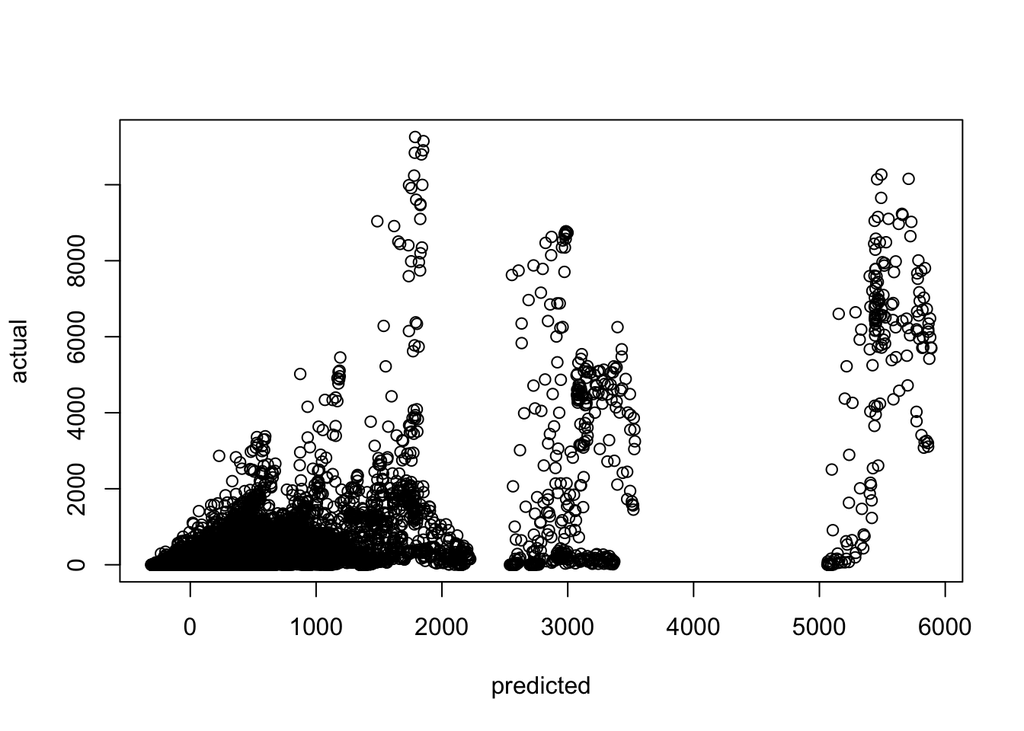

```r
trainlm <- lm(target ~ as.factor(is_business) + as.factor(is_consumption) + temperature + direct_solar_radiation + total_precipitation + dewpoint + eic_count + installed_capacity + lowest_price_per_mwh + euros_per_mwh, data = train)

predicted <- predict(trainlm, newdata = test %>% select(is_business, temperature,direct_solar_radiation, total_precipitation, dewpoint, eic_count, installed_capacity, lowest_price_per_mwh, euros_per_mwh, is_consumption))

actual <- test$target

plot(actual ~ predicted)
```

```r
mae <- (1/length(actual))*sum(abs(actual - predicted))
```

mae = 460.047

Doesn’t show significant improvement

## Transformations

### With log transformation

```r
trainlm <- lm(log(target+0.5) ~ as.factor(is_business) + as.factor(is_consumption) + as.factor(product_type) + temperature + direct_solar_radiation + total_precipitation + dewpoint + eic_count + installed_capacity + lowest_price_per_mwh + euros_per_mwh, data = train)

predicted <- predict(trainlm, newdata = test %>% select(is_business, temperature,direct_solar_radiation, total_precipitation, dewpoint, eic_count, installed_capacity, lowest_price_per_mwh, euros_per_mwh, is_consumption, product_type))

mae <- (1/length(actual))*sum(abs(actual - predicted))
```

mae = 390.6284

Some improvement

Note: is_consumption still treated as factor

### With reciprocal transformation

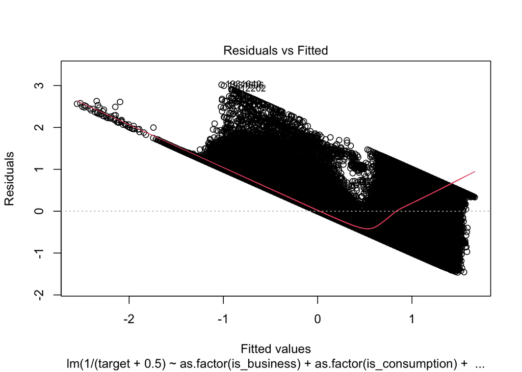

```r
trainlm <- lm(1/(target+.5) ~ as.factor(is_business) + as.factor(is_consumption) + as.factor(product_type) + temperature + direct_solar_radiation + total_precipitation + dewpoint + eic_count + installed_capacity + lowest_price_per_mwh + euros_per_mwh, data = train)

predicted <- predict(trainlm, newdata = test %>% select(is_business, temperature,direct_solar_radiation, total_precipitation, dewpoint, eic_count, installed_capacity, lowest_price_per_mwh, euros_per_mwh, is_consumption, product_type))

mae <- (1/length(actual))*sum(abs(actual - predicted))
plot(trainlm, which = 1)
```

mae = 395.1988

No improvement

### With exponential

```r
trainlm <- lm(is.finite(exp(target)) ~ as.factor(is_business) + as.factor(is_consumption) + as.factor(product_type) + temperature + direct_solar_radiation + total_precipitation + dewpoint + eic_count + installed_capacity + lowest_price_per_mwh + euros_per_mwh, data = train)

predicted <- predict(trainlm, newdata = test %>% select(is_business, temperature,direct_solar_radiation, total_precipitation, dewpoint, eic_count, installed_capacity, lowest_price_per_mwh, euros_per_mwh, is_consumption, product_type))

mae <- (1/length(actual))*sum(abs(actual - predicted))
```

mae = 721.2031

Considerably worse

## Random Forest Model

```r
#generate random smaller train set, since full set exceeds memory limit
set.seed(43)
production <- train[train$is_consumption ==1,]
small_index <- sample(nrow(train), size = 50000)
small_train <- train[small_index, ]

trainrf <- randomForest(target ~ is_consumption + is_business + temperature + direct_solar_radiation + total_precipitation + dewpoint + eic_count + installed_capacity + lowest_price_per_mwh + euros_per_mwh, data = small_train)

predicted <- predict(trainrf, newdata = test %>% select(is_consumption, is_business, temperature,direct_solar_radiation, total_precipitation, dewpoint, eic_count, installed_capacity, lowest_price_per_mwh, euros_per_mwh))

actual = test$target

mae <- (1/length(actual))*sum(abs(actual - predicted))
```

mae = 262.1787

Given that this resulting Mean Absolute Error is higher than when following the same process for Merge Version 2, further refining of the model will be done using the Merge V2 sets.